# Advanced Data Analysis Course - Pre-Course Refresher Exercises

Ronnie Bailey-Steinitz

2026-04-15

# Pre-Course Refresher Workshop

## Purpose

This refresher is designed to review the most important skills from last year’s introductory R course before we begin the 6-week Advanced Data Analysis course. You have already seen most of these tools before. The goal is to rebuild confidence, refresh your memory, and get everyone ready to move into more advanced statistical thinking.

This refresher is divided into two sessions:

- **Week 1: Basics** — project setup, working directories, importing data, exploratory summaries, and basic plots
- **Week 2: Wrangling** — data wrangling, joins, simple models, transformations, and a short applied challenge

# Week 1: Basics

## 1. Setup

Before we begin any coding, we need to make sure your files are organized correctly. Good file organization will save you a lot of confusion later in the course.

### 1A. Set up your course folder

For this course, you should keep **all course materials in one main folder** on your computer.

#### Step 1: Create a main course folder

Create a new folder somewhere easy to find on your computer. For example:

`Advanced_data_analysis_course`

#### Step 2: Create a subfolder for this workshop

Inside that main folder, create a second folder called:

`pre-course refresher`

Your folder structure should look something like this:

`Advanced_data_analysis_course/`  
└── `pre-course refresher/`

#### Step 3: Move your downloaded files

You downloaded these two files from Google Drive into your Downloads folder:

`Radac_refresher_exercises.Rmd`  
`Palmer Penguins Raw.csv`

Move both files from Downloads into the `pre-course refresher` folder.

So now your folder should look like this:

`Advanced_data_analysis_course/`  
└── `pre-course refresher/`  
└── `Radac_refresher_exercises.Rmd`  
└── `Palmer Penguins Raw.csv`

### 1B. Check file names carefully

File names in R must match exactly.

That means:

- uppercase and lowercase letters matter
- spaces matter
- punctuation matters
- file extensions matter

For example:

`Palmer Penguins Raw.csv` is **not** the same as:

- `palmer penguins raw.csv`
- `Palmer_penguins_raw.csv`
- `Palmer Penguins Raw.CSV`
- `Palmer Penguins Raw`

Also make sure the file is really a `.csv` file and the R Markdown file is really an `.Rmd` file.

### 1C. Create an R Project

We will use an R Project for this course. This is important because it helps RStudio automatically keep track of the correct working directory.

1. Open RStudio
2. Go to: `File > New Project`
3. Choose: `Existing Directory`
4. Navigate to your main course folder:  
   `Advanced_data_analysis_course`
5. Click `Create Project`

RStudio should now reopen inside your course project.

### 1D. Open the refresher file from inside the project

Once the project opens:

1. In the `Files` pane, click into the `pre-course refresher` folder
2. Open `Radac_refresher_exercises.Rmd`

You should now be working inside the correct project.

### 1E. What is a working directory?

Your working directory is the folder R is currently using to look for files and save output.

Because you opened an R Project, your working directory should now be:

`.../Advanced_data_analysis_course`

That means your `.csv` file is inside a subfolder called:

`pre-course refresher`

### 1F. Check your working directory

Run:

```r
getwd()
```

```
## [1] "/Users/rsteinitz/Documents/github/R Advanced Data Analysis/pre-course refresher"
```

Your output should end with something like:

### 1G. Check that R can see your files

Run:

```r
list.files()
```

```
## [1] "penguins.csv"                    "Radac pre-course refresher.Rmd"
## [3] "Radac-pre-course-refresher.html" "Radac-pre-course-refresher.Rmd"
```

You should see:

Now run:

```r
list.files("pre-course refresher")
```

```
## character(0)
```

## 2. Load Packages

```r
# install the package only if you have not yet, although you should have it already installed;
# you might want to update by re-installing!
# ---------
# install.packages(c("tidyverse", "here", "janitor"))

# load packages
library(tidyverse)
library(here)
library(janitor)
```

## 3. Import a Dataset

Because your `.csv` file is inside the `pre-course refresher` folder, use this path:

```r
penguins <- readr::read_csv(here::here("pre-course refresher/penguins.csv")) %>%
  janitor::clean_names()
```

```
## ──────────────────────────────────────────────────────── Delimiter: "," chr
## (11): study_name, species, region, island, stage, individual_id, clutch_... dbl
## (8): ...1, sample_number, bill_length_mm, bill_depth_mm, flipper_length...
```

Then inspect it:

```r
dplyr::glimpse(penguins)
```

```
## Rows: 333
## Columns: 19
## $ x1                <dbl> 1, 2, 3, 4, 5, 6, 7, 8, 9, 10, 11, 12, 13, 14, 15, 1…
## $ study_name        <chr> "PAL0708", "PAL0708", "PAL0708", "PAL0708", "PAL0708…
## $ sample_number     <dbl> 1, 2, 3, 5, 6, 7, 8, 13, 14, 15, 16, 17, 18, 19, 20,…
## $ species           <chr> "Adelie", "Adelie", "Adelie", "Adelie", "Adelie", "A…
## $ region            <chr> "Anvers", "Anvers", "Anvers", "Anvers", "Anvers", "A…
## $ island            <chr> "Torgersen", "Torgersen", "Torgersen", "Torgersen", …
## $ stage             <chr> "Adult, 1 Egg Stage", "Adult, 1 Egg Stage", "Adult, …
## $ individual_id     <chr> "N1A1", "N1A2", "N2A1", "N3A1", "N3A2", "N4A1", "N4A…
## $ clutch_completion <chr> "Yes", "Yes", "Yes", "Yes", "Yes", "No", "No", "Yes"…
## $ date_egg          <chr> "11/11/07", "11/11/07", "11/16/07", "11/16/07", "11/…
## $ bill_length_mm    <dbl> 39.1, 39.5, 40.3, 36.7, 39.3, 38.9, 39.2, 41.1, 38.6…
## $ bill_depth_mm     <dbl> 18.7, 17.4, 18.0, 19.3, 20.6, 17.8, 19.6, 17.6, 21.2…
## $ flipper_length_mm <dbl> 181, 186, 195, 193, 190, 181, 195, 182, 191, 198, 18…
## $ body_mass_g       <dbl> 3750, 3800, 3250, 3450, 3650, 3625, 4675, 3200, 3800…
## $ sex               <chr> "MALE", "FEMALE", "FEMALE", "FEMALE", "MALE", "FEMAL…
## $ delta_15_n_o_oo   <dbl> NA, 8.94956, 8.36821, 8.76651, 8.66496, 9.18718, 9.4…
## $ delta_13_c_o_oo   <dbl> NA, -24.69454, -25.33302, -25.32426, -25.29805, -25.…
## $ comments          <chr> "Not enough blood for isotopes.", NA, NA, NA, NA, "N…
## $ date_e            <chr> "11/11/07", "11/11/07", "11/16/07", "11/16/07", "11/…
```

## 4. Warm-Up: Explore the Data

We will use the penguins dataset for most exercises because it contains a mix of numeric and categorical variables and includes some missing values.

### Exercise 1: First look

Run the following commands and write 1-2 sentences describing what you notice about the dataset.

```r
dplyr::glimpse(penguins)
```

```
## Rows: 333
## Columns: 19
## $ x1                <dbl> 1, 2, 3, 4, 5, 6, 7, 8, 9, 10, 11, 12, 13, 14, 15, 1…
## $ study_name        <chr> "PAL0708", "PAL0708", "PAL0708", "PAL0708", "PAL0708…
## $ sample_number     <dbl> 1, 2, 3, 5, 6, 7, 8, 13, 14, 15, 16, 17, 18, 19, 20,…
## $ species           <chr> "Adelie", "Adelie", "Adelie", "Adelie", "Adelie", "A…
## $ region            <chr> "Anvers", "Anvers", "Anvers", "Anvers", "Anvers", "A…
## $ island            <chr> "Torgersen", "Torgersen", "Torgersen", "Torgersen", …
## $ stage             <chr> "Adult, 1 Egg Stage", "Adult, 1 Egg Stage", "Adult, …
## $ individual_id     <chr> "N1A1", "N1A2", "N2A1", "N3A1", "N3A2", "N4A1", "N4A…
## $ clutch_completion <chr> "Yes", "Yes", "Yes", "Yes", "Yes", "No", "No", "Yes"…
## $ date_egg          <chr> "11/11/07", "11/11/07", "11/16/07", "11/16/07", "11/…
## $ bill_length_mm    <dbl> 39.1, 39.5, 40.3, 36.7, 39.3, 38.9, 39.2, 41.1, 38.6…
## $ bill_depth_mm     <dbl> 18.7, 17.4, 18.0, 19.3, 20.6, 17.8, 19.6, 17.6, 21.2…
## $ flipper_length_mm <dbl> 181, 186, 195, 193, 190, 181, 195, 182, 191, 198, 18…
## $ body_mass_g       <dbl> 3750, 3800, 3250, 3450, 3650, 3625, 4675, 3200, 3800…
## $ sex               <chr> "MALE", "FEMALE", "FEMALE", "FEMALE", "MALE", "FEMAL…
## $ delta_15_n_o_oo   <dbl> NA, 8.94956, 8.36821, 8.76651, 8.66496, 9.18718, 9.4…
## $ delta_13_c_o_oo   <dbl> NA, -24.69454, -25.33302, -25.32426, -25.29805, -25.…
## $ comments          <chr> "Not enough blood for isotopes.", NA, NA, NA, NA, "N…
## $ date_e            <chr> "11/11/07", "11/11/07", "11/16/07", "11/16/07", "11/…
```

```r
summary(penguins) # summary of the dataset
```

```
##        x1       study_name        sample_number      species
##  Min.   :  1   Length:333         Min.   :  1.00   Length:333
##  1st Qu.: 84   Class :character   1st Qu.: 30.00   Class :character
##  Median :167   Mode  :character   Median : 58.00   Mode  :character
##  Mean   :167                      Mean   : 63.65
##  3rd Qu.:250                      3rd Qu.: 95.00
##  Max.   :333                      Max.   :152.00
##
##     region             island             stage           individual_id
##  Length:333         Length:333         Length:333         Length:333
##  Class :character   Class :character   Class :character   Class :character
##  Mode  :character   Mode  :character   Mode  :character   Mode  :character
##
##
##
##
##  clutch_completion    date_egg         bill_length_mm  bill_depth_mm
##  Length:333         Length:333         Min.   :32.10   Min.   :13.10
##  Class :character   Class :character   1st Qu.:39.50   1st Qu.:15.60
##  Mode  :character   Mode  :character   Median :44.50   Median :17.30
##                                        Mean   :43.99   Mean   :17.16
##                                        3rd Qu.:48.60   3rd Qu.:18.70
##                                        Max.   :59.60   Max.   :21.50
##
##  flipper_length_mm  body_mass_g       sex            delta_15_n_o_oo
##  Min.   :172       Min.   :2700   Length:333         Min.   : 7.632
##  1st Qu.:190       1st Qu.:3550   Class :character   1st Qu.: 8.304
##  Median :197       Median :4050   Mode  :character   Median : 8.659
##  Mean   :201       Mean   :4207                      Mean   : 8.740
##  3rd Qu.:213       3rd Qu.:4775                      3rd Qu.: 9.181
##  Max.   :231       Max.   :6300                      Max.   :10.025
##                                                      NA's   :9
##  delta_13_c_o_oo    comments            date_e
##  Min.   :-27.02   Length:333         Length:333
##  1st Qu.:-26.33   Class :character   Class :character
##  Median :-25.83   Mode  :character   Mode  :character
##  Mean   :-25.68
##  3rd Qu.:-25.04
##  Max.   :-23.79
##  NA's   :8
```

```r
head(penguins) # shows the first 6 rows
```

```
## # A tibble: 6 × 19
##      x1 study_name sample_number species region island    stage    individual_id
##   <dbl> <chr>              <dbl> <chr>   <chr>  <chr>     <chr>    <chr>
## 1     1 PAL0708                1 Adelie  Anvers Torgersen Adult, … N1A1
## 2     2 PAL0708                2 Adelie  Anvers Torgersen Adult, … N1A2
## 3     3 PAL0708                3 Adelie  Anvers Torgersen Adult, … N2A1
## 4     4 PAL0708                5 Adelie  Anvers Torgersen Adult, … N3A1
## 5     5 PAL0708                6 Adelie  Anvers Torgersen Adult, … N3A2
## 6     6 PAL0708                7 Adelie  Anvers Torgersen Adult, … N4A1
## # ℹ 11 more variables: clutch_completion <chr>, date_egg <chr>,
## #   bill_length_mm <dbl>, bill_depth_mm <dbl>, flipper_length_mm <dbl>,
## #   body_mass_g <dbl>, sex <chr>, delta_15_n_o_oo <dbl>, delta_13_c_o_oo <dbl>,
## #   comments <chr>, date_e <chr>
```

```r
tail(penguins) # shows the last 6 rows
```

```
## # A tibble: 6 × 19
##      x1 study_name sample_number species   region island stage     individual_id
##   <dbl> <chr>              <dbl> <chr>     <chr>  <chr>  <chr>     <chr>
## 1   328 PAL0910               63 Chinstrap Anvers Dream  Adult, 1… N98A1
## 2   329 PAL0910               64 Chinstrap Anvers Dream  Adult, 1… N98A2
## 3   330 PAL0910               65 Chinstrap Anvers Dream  Adult, 1… N99A1
## 4   331 PAL0910               66 Chinstrap Anvers Dream  Adult, 1… N99A2
## 5   332 PAL0910               67 Chinstrap Anvers Dream  Adult, 1… N100A1
## 6   333 PAL0910               68 Chinstrap Anvers Dream  Adult, 1… N100A2
## # ℹ 11 more variables: clutch_completion <chr>, date_egg <chr>,
## #   bill_length_mm <dbl>, bill_depth_mm <dbl>, flipper_length_mm <dbl>,
## #   body_mass_g <dbl>, sex <chr>, delta_15_n_o_oo <dbl>, delta_13_c_o_oo <dbl>,
## #   comments <chr>, date_e <chr>
```

```r
nrow(penguins) # number of rows, or observations
```

```
## [1] 333
```

```r
ncol(penguins) # number of columns, or variables
```

```
## [1] 19
```

**Questions**

1. How many rows and columns are in the dataset?
2. Which variables are numeric?
3. Which variables are categorical?
4. Do you notice any missing values?

## 5. Exploratory Plots

Before making polished plots with `ggplot2`, it can be useful to make quick exploratory plots.

### Exercise 2: Quick histograms with base R

Use `hist()` to look at the distribution of body mass and flipper length.

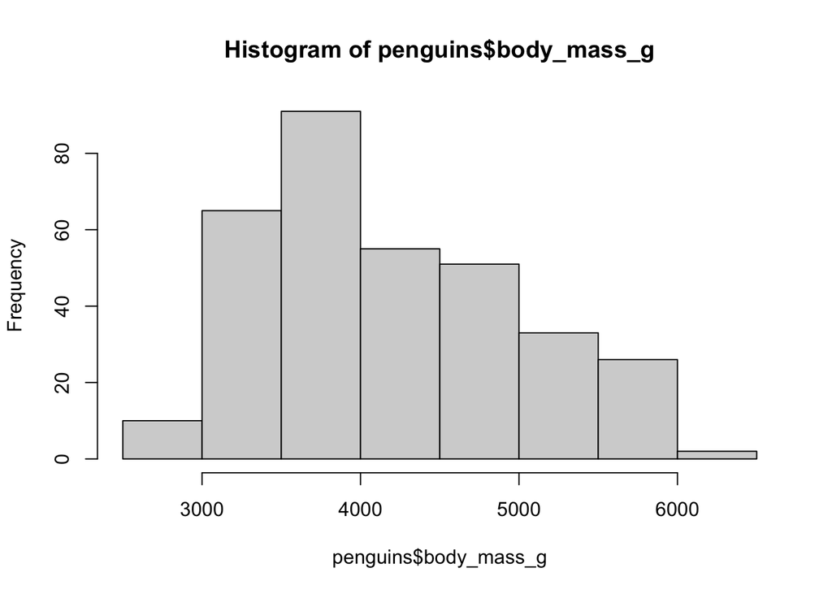

```r
hist(penguins$body_mass_g)
```

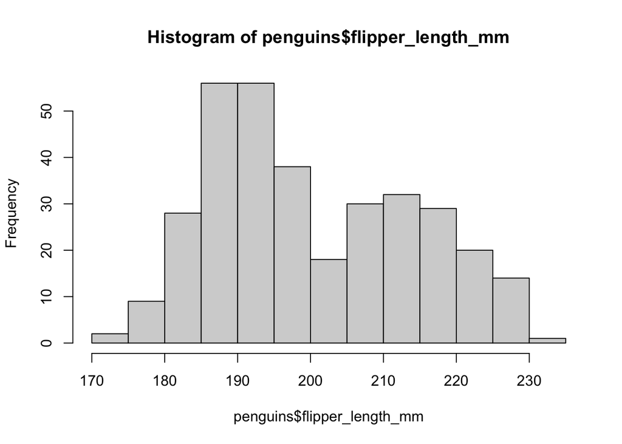

```r
hist(penguins$flipper_length_mm)
```

**Questions**

1. What does each histogram show you?
2. What does the y-axis mean?
3. Do either of these variables look skewed?
4. Are there any values that look unusual?

## 6. Review of Visualization with ggplot2

### Exercise 3: Scatterplot

Make a scatterplot of bill length vs. bill depth, colored by species.

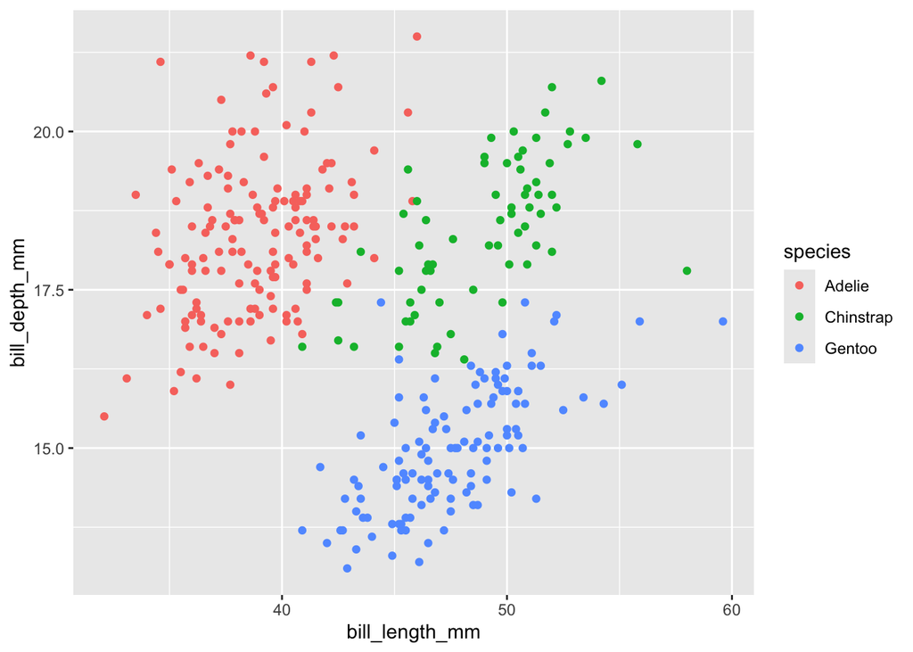

```r
ggplot2::ggplot(penguins, ggplot2::aes(x = bill_length_mm, y = bill_depth_mm, color = species)) +
  ggplot2::geom_point()
```

### Exercise 4: Boxplot

Make a boxplot of body mass by species.

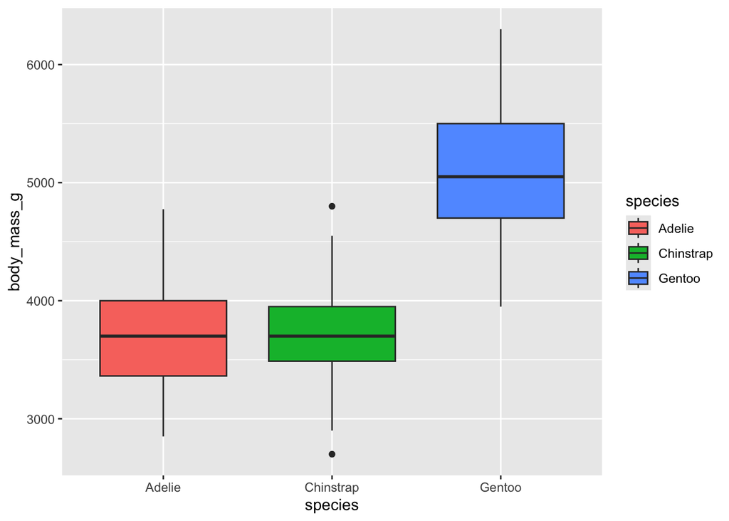

```r
ggplot2::ggplot(penguins, ggplot2::aes(x = species, y = body_mass_g, fill = species)) +
  ggplot2::geom_boxplot()
```

### Exercise 5: Histogram

Make a histogram of flipper length.

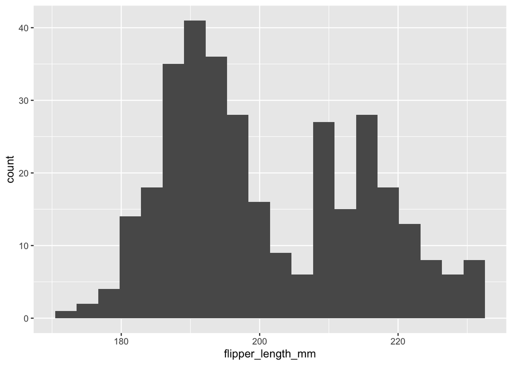

```r
ggplot2::ggplot(penguins, ggplot2::aes(x = flipper_length_mm)) +
  ggplot2::geom_histogram(bins = 20)
```

### Exercise 6: Improve one plot

Choose one of the plots above and improve it by adding:

- a title
- better axis labels
- custom colors
- a cleaner theme

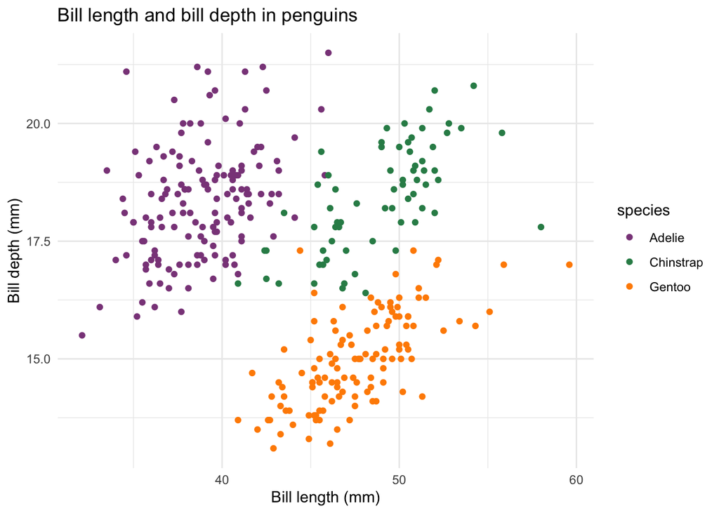

```r
ggplot2::ggplot(penguins, ggplot2::aes(x = bill_length_mm, y = bill_depth_mm, color = species)) +
  ggplot2::geom_point() +
  ggplot2::labs(
    title = "Bill length and bill depth in penguins",
    x = "Bill length (mm)",
    y = "Bill depth (mm)"
  ) +
  scale_color_manual(values = c("orchid4", "seagreen", "darkorange")) +
  ggplot2::theme_minimal()
```

**Questions**

1. Which type of plot is best for comparing groups?
2. Which type is best for showing the relationship between two numeric variables?
3. Which plot would you use to check the distribution of one numeric variable?

# Week 2: Wrangling

## 7. Selecting, Filtering, and Creating Variables

### Exercise 7: Select only a few columns

Create a new object called `penguins_small` that includes only these variables:

- `species`
- `island`
- `sex`
- `bill_length_mm`
- `bill_depth_mm`
- `body_mass_g`

```r
penguins_small <- penguins %>%
  dplyr::select(species, island, sex, bill_length_mm, bill_depth_mm, body_mass_g)

penguins_small
```

```
## # A tibble: 333 × 6
##    species island    sex    bill_length_mm bill_depth_mm body_mass_g
##    <chr>   <chr>     <chr>           <dbl>         <dbl>       <dbl>
##  1 Adelie  Torgersen MALE             39.1          18.7        3750
##  2 Adelie  Torgersen FEMALE           39.5          17.4        3800
##  3 Adelie  Torgersen FEMALE           40.3          18          3250
##  4 Adelie  Torgersen FEMALE           36.7          19.3        3450
##  5 Adelie  Torgersen MALE             39.3          20.6        3650
##  6 Adelie  Torgersen FEMALE           38.9          17.8        3625
##  7 Adelie  Torgersen MALE             39.2          19.6        4675
##  8 Adelie  Torgersen FEMALE           41.1          17.6        3200
##  9 Adelie  Torgersen MALE             38.6          21.2        3800
## 10 Adelie  Torgersen MALE             34.6          21.1        4400
## # ℹ 323 more rows
```

### Exercise 8: Filter rows

Create a dataset called `female_penguins` that includes only female penguins with non-missing body mass values.

```r
female_penguins <- penguins %>%
  dplyr::filter(sex == "FEMALE", !is.na(body_mass_g))

glimpse(female_penguins)
```

```
## Rows: 165
## Columns: 19
## $ x1                <dbl> 2, 3, 4, 6, 8, 11, 12, 14, 16, 18, 21, 23, 24, 26, 2…
## $ study_name        <chr> "PAL0708", "PAL0708", "PAL0708", "PAL0708", "PAL0708…
## $ sample_number     <dbl> 2, 3, 5, 7, 13, 16, 17, 19, 21, 23, 26, 28, 29, 31, …
## $ species           <chr> "Adelie", "Adelie", "Adelie", "Adelie", "Adelie", "A…
## $ region            <chr> "Anvers", "Anvers", "Anvers", "Anvers", "Anvers", "A…
## $ island            <chr> "Torgersen", "Torgersen", "Torgersen", "Torgersen", …
## $ stage             <chr> "Adult, 1 Egg Stage", "Adult, 1 Egg Stage", "Adult, …
## $ individual_id     <chr> "N1A2", "N2A1", "N3A1", "N4A1", "N7A1", "N8A2", "N9A…
## $ clutch_completion <chr> "Yes", "Yes", "Yes", "No", "Yes", "Yes", "Yes", "Yes…
## $ date_egg          <chr> "11/11/07", "11/16/07", "11/16/07", "11/15/07", "11/…
## $ bill_length_mm    <dbl> 39.5, 40.3, 36.7, 38.9, 41.1, 36.6, 38.7, 34.4, 37.8…
## $ bill_depth_mm     <dbl> 17.4, 18.0, 19.3, 17.8, 17.6, 17.8, 19.0, 18.4, 18.3…
## $ flipper_length_mm <dbl> 186, 195, 193, 181, 182, 185, 195, 184, 174, 189, 18…
## $ body_mass_g       <dbl> 3800, 3250, 3450, 3625, 3200, 3700, 3450, 3325, 3400…
## $ sex               <chr> "FEMALE", "FEMALE", "FEMALE", "FEMALE", "FEMALE", "F…
## $ delta_15_n_o_oo   <dbl> 8.94956, 8.36821, 8.76651, 9.18718, NA, NA, 9.18528,…
## $ delta_13_c_o_oo   <dbl> -24.69454, -25.33302, -25.32426, -25.21799, NA, NA, …
## $ comments          <chr> NA, NA, NA, "Nest never observed with full clutch.",…
## $ date_e            <chr> "11/11/07", "11/16/07", "11/16/07", "11/15/07", "11/…
```

**Question**  
How many female penguins are in this filtered dataset?

```r
nrow(female_penguins) # you can also look in your "Environment" panel, and see the number of observations in the object `female_penguins`
```

```
## [1] 165
```

### Exercise 9: Make new variables

Use `dplyr::mutate()` to create:

- `body_mass_kg` = body mass in kilograms
- `bill_ratio` = bill length divided by bill depth

```r
penguins_new <- penguins %>%
  dplyr::mutate(
    body_mass_kg = body_mass_g / 1000,
    bill_ratio = bill_length_mm / bill_depth_mm
  )

glimpse(penguins_new)
```

```
## Rows: 333
## Columns: 21
## $ x1                <dbl> 1, 2, 3, 4, 5, 6, 7, 8, 9, 10, 11, 12, 13, 14, 15, 1…
## $ study_name        <chr> "PAL0708", "PAL0708", "PAL0708", "PAL0708", "PAL0708…
## $ sample_number     <dbl> 1, 2, 3, 5, 6, 7, 8, 13, 14, 15, 16, 17, 18, 19, 20,…
## $ species           <chr> "Adelie", "Adelie", "Adelie", "Adelie", "Adelie", "A…
## $ region            <chr> "Anvers", "Anvers", "Anvers", "Anvers", "Anvers", "A…
## $ island            <chr> "Torgersen", "Torgersen", "Torgersen", "Torgersen", …
## $ stage             <chr> "Adult, 1 Egg Stage", "Adult, 1 Egg Stage", "Adult, …
## $ individual_id     <chr> "N1A1", "N1A2", "N2A1", "N3A1", "N3A2", "N4A1", "N4A…
## $ clutch_completion <chr> "Yes", "Yes", "Yes", "Yes", "Yes", "No", "No", "Yes"…
## $ date_egg          <chr> "11/11/07", "11/11/07", "11/16/07", "11/16/07", "11/…
## $ bill_length_mm    <dbl> 39.1, 39.5, 40.3, 36.7, 39.3, 38.9, 39.2, 41.1, 38.6…
## $ bill_depth_mm     <dbl> 18.7, 17.4, 18.0, 19.3, 20.6, 17.8, 19.6, 17.6, 21.2…
## $ flipper_length_mm <dbl> 181, 186, 195, 193, 190, 181, 195, 182, 191, 198, 18…
## $ body_mass_g       <dbl> 3750, 3800, 3250, 3450, 3650, 3625, 4675, 3200, 3800…
## $ sex               <chr> "MALE", "FEMALE", "FEMALE", "FEMALE", "MALE", "FEMAL…
## $ delta_15_n_o_oo   <dbl> NA, 8.94956, 8.36821, 8.76651, 8.66496, 9.18718, 9.4…
## $ delta_13_c_o_oo   <dbl> NA, -24.69454, -25.33302, -25.32426, -25.29805, -25.…
## $ comments          <chr> "Not enough blood for isotopes.", NA, NA, NA, NA, "N…
## $ date_e            <chr> "11/11/07", "11/11/07", "11/16/07", "11/16/07", "11/…
## $ body_mass_kg      <dbl> 3.750, 3.800, 3.250, 3.450, 3.650, 3.625, 4.675, 3.2…
## $ bill_ratio        <dbl> 2.090909, 2.270115, 2.238889, 1.901554, 1.907767, 2.…
```

**Questions**

1. Why might `body_mass_kg` be useful?
2. Why might `bill_ratio` be useful?
3. What happens to `bill_ratio` if either bill measurement is missing?

## 8. Grouping and Summarizing

### Exercise 10: Summarize by species

Calculate the following for each species:

- number of penguins
- mean body mass
- mean flipper length

```r
species_summary <- penguins %>%
  dplyr::group_by(species) %>%
  dplyr::summarise(
    n = dplyr::n(),
    mean_body_mass = mean(body_mass_g, na.rm = TRUE),
    mean_flipper = mean(flipper_length_mm, na.rm = TRUE)
  )

species_summary
```

```
## # A tibble: 3 × 4
##   species       n mean_body_mass mean_flipper
##   <chr>     <int>          <dbl>        <dbl>
## 1 Adelie      146          3706.         190.
## 2 Chinstrap    68          3733.         196.
## 3 Gentoo      119          5092.         217.
```

### Exercise 11: Summarize by species and sex

Now calculate mean body mass by both species and sex.

```r
species_sex_summary <- penguins %>%
  dplyr::group_by(species, sex) %>%
  dplyr::summarise(
    mean_body_mass = mean(body_mass_g, na.rm = TRUE),
    n = dplyr::n(),
    .groups = "drop"
  )

species_sex_summary
```

```
## # A tibble: 6 × 4
##   species   sex    mean_body_mass     n
##   <chr>     <chr>           <dbl> <int>
## 1 Adelie    FEMALE          3369.    73
## 2 Adelie    MALE            4043.    73
## 3 Chinstrap FEMALE          3527.    34
## 4 Chinstrap MALE            3939.    34
## 5 Gentoo    FEMALE          4680.    58
## 6 Gentoo    MALE            5485.    61
```

**Questions**

1. Which species appears heaviest on average?
2. Within species, do males and females differ in body mass?
3. Why is it useful to include `n` when summarizing by group?

## 9. Joining Data

Sometimes your data are split across multiple files. To practice joining, we will create a small second dataset.

```r
island_info <- tibble::tibble(
  island = c("Biscoe", "Dream", "Torgersen"), # these are the given islands
  area = c("West", "Central", "East") # these are the regions affiliated with each island-- what we want to **add** to the dataset
)

island_info
```

```
## # A tibble: 3 × 2
##   island    area
##   <chr>     <chr>
## 1 Biscoe    West
## 2 Dream     Central
## 3 Torgersen East
```

### Exercise 12: Join the datasets

```r
penguins_joined <- penguins %>%
  dplyr::left_join(island_info, by = "island") # we joined the "area" information by "island." Each observation now has information about the area that is associated with its island.

glimpse(penguins_joined)
```

```
## Rows: 333
## Columns: 20
## $ x1                <dbl> 1, 2, 3, 4, 5, 6, 7, 8, 9, 10, 11, 12, 13, 14, 15, 1…
## $ study_name        <chr> "PAL0708", "PAL0708", "PAL0708", "PAL0708", "PAL0708…
## $ sample_number     <dbl> 1, 2, 3, 5, 6, 7, 8, 13, 14, 15, 16, 17, 18, 19, 20,…
## $ species           <chr> "Adelie", "Adelie", "Adelie", "Adelie", "Adelie", "A…
## $ region            <chr> "Anvers", "Anvers", "Anvers", "Anvers", "Anvers", "A…
## $ island            <chr> "Torgersen", "Torgersen", "Torgersen", "Torgersen", …
## $ stage             <chr> "Adult, 1 Egg Stage", "Adult, 1 Egg Stage", "Adult, …
## $ individual_id     <chr> "N1A1", "N1A2", "N2A1", "N3A1", "N3A2", "N4A1", "N4A…
## $ clutch_completion <chr> "Yes", "Yes", "Yes", "Yes", "Yes", "No", "No", "Yes"…
## $ date_egg          <chr> "11/11/07", "11/11/07", "11/16/07", "11/16/07", "11/…
## $ bill_length_mm    <dbl> 39.1, 39.5, 40.3, 36.7, 39.3, 38.9, 39.2, 41.1, 38.6…
## $ bill_depth_mm     <dbl> 18.7, 17.4, 18.0, 19.3, 20.6, 17.8, 19.6, 17.6, 21.2…
## $ flipper_length_mm <dbl> 181, 186, 195, 193, 190, 181, 195, 182, 191, 198, 18…
## $ body_mass_g       <dbl> 3750, 3800, 3250, 3450, 3650, 3625, 4675, 3200, 3800…
## $ sex               <chr> "MALE", "FEMALE", "FEMALE", "FEMALE", "MALE", "FEMAL…
## $ delta_15_n_o_oo   <dbl> NA, 8.94956, 8.36821, 8.76651, 8.66496, 9.18718, 9.4…
## $ delta_13_c_o_oo   <dbl> NA, -24.69454, -25.33302, -25.32426, -25.29805, -25.…
## $ comments          <chr> "Not enough blood for isotopes.", NA, NA, NA, NA, "N…
## $ date_e            <chr> "11/11/07", "11/11/07", "11/16/07", "11/16/07", "11/…
## $ area              <chr> "East", "East", "East", "East", "East", "East", "Eas…
```

**Questions**

1. Did the number of rows change after the join? Why or why not?
2. What would happen if one island name were misspelled in one of the datasets?
3. Why do we need a shared column when joining datasets?

## 10. Review of Linear Models

We will fit a simple linear model to test whether flipper length predicts body mass.

### Exercise 13: Fit a model

First remove missing values for the two variables.

```r
model_data <- penguins %>%
  dplyr::filter(!is.na(flipper_length_mm), !is.na(body_mass_g))
```

Fit the model:

```r
mod1 <- lm(body_mass_g ~ flipper_length_mm, data = model_data)

summary(mod1)
```

```
##
## Call:
## lm(formula = body_mass_g ~ flipper_length_mm, data = model_data)
##
## Residuals:
##      Min       1Q   Median       3Q      Max
## -1057.33  -259.79   -12.24   242.97  1293.89
##
## Coefficients:
##                   Estimate Std. Error t value Pr(>|t|)
## (Intercept)       -5872.09     310.29  -18.93   <2e-16 ***
## flipper_length_mm    50.15       1.54   32.56   <2e-16 ***
## ---
## Signif. codes:  0 '***' 0.001 '**' 0.01 '*' 0.05 '.' 0.1 ' ' 1
##
## Residual standard error: 393.3 on 331 degrees of freedom
## Multiple R-squared:  0.7621, Adjusted R-squared:  0.7614
## F-statistic:  1060 on 1 and 331 DF,  p-value: < 2.2e-16
```

### Questions

1. What is the response (outcome) variable in this model?
2. What is the predictor variable in this model?
3. Is the relationship between flipper length and body mass positive or negative? How can you tell from the output?
4. What does the intercept represent? Does it make biological sense in this case?
5. What does the p-value tell you about the relationship between flipper length and body mass?
6. What does the R-squared value tell you?

### Exercise 14: Visualize the model

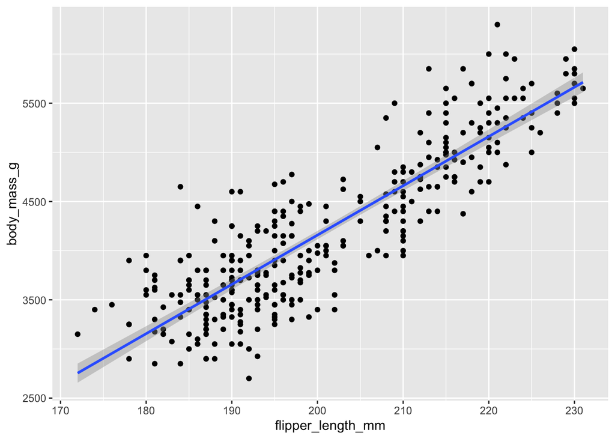

```r
ggplot2::ggplot(model_data, ggplot2::aes(x = flipper_length_mm, y = body_mass_g)) +
  ggplot2::geom_point() +
  ggplot2::geom_smooth(method = "lm", se = TRUE)
```

**Questions**

1. Does this visualized relationship match the model output from the linear regression?
2. What does the slope mean in this model, biologically?

## 11. Transformations

In the advanced course, we will work more carefully with assumptions and model fit. Transformations are one tool that can help.

### Exercise 15: Log-transform a variable

Create a log-transformed version of body mass.

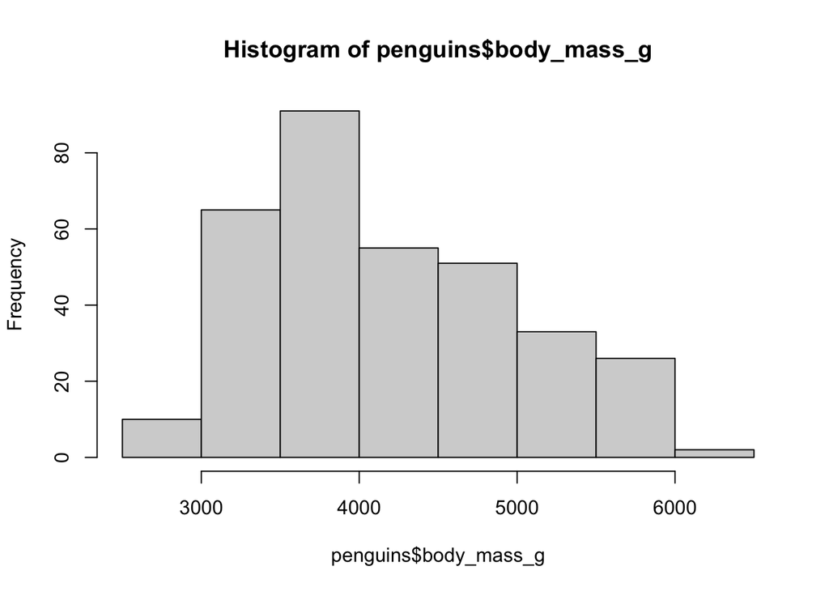

```r
hist(penguins$body_mass_g)
```

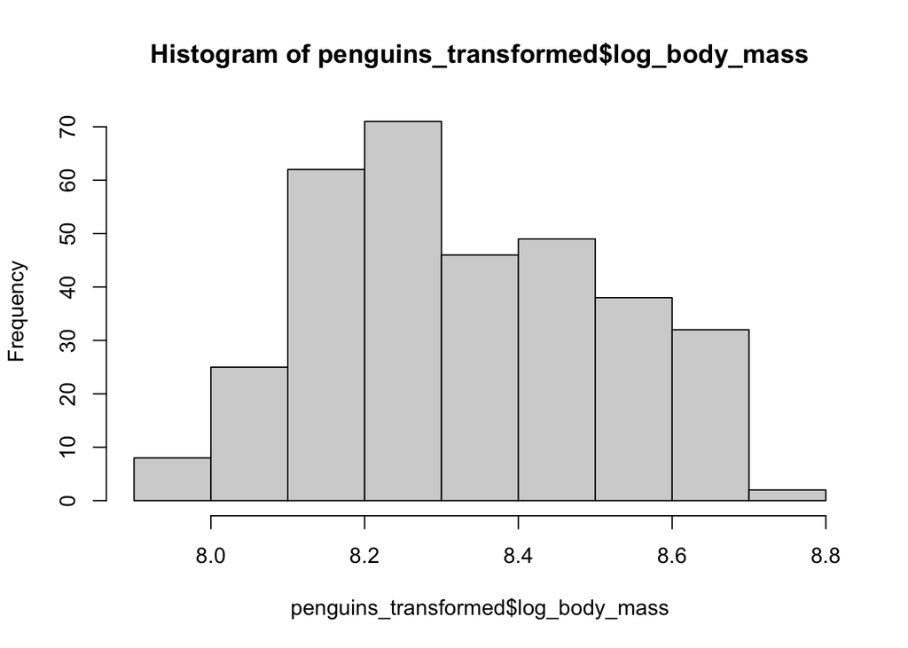

```r
penguins_transformed <- penguins %>%
  dplyr::filter(!is.na(body_mass_g)) %>%
  dplyr::mutate(
    log_body_mass = log(body_mass_g)
  )

hist(penguins_transformed$log_body_mass)
```

### Exercise 16: Standardize a variable

Use `scale()` to standardize flipper length.

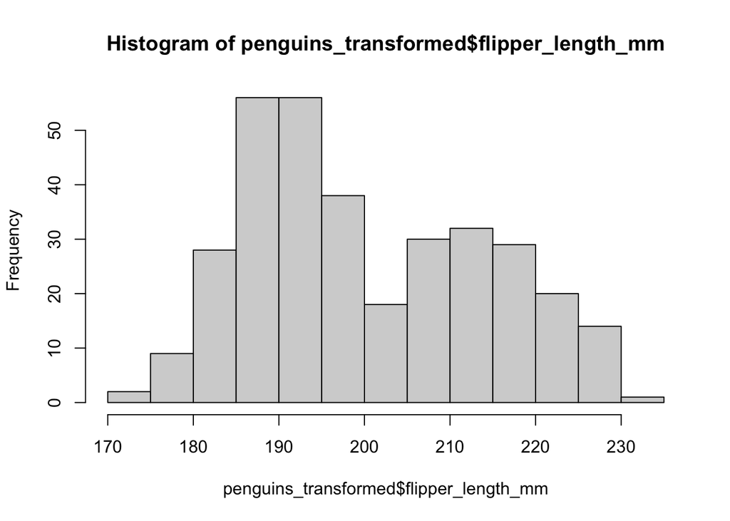

```r
hist(penguins_transformed$flipper_length_mm)
```

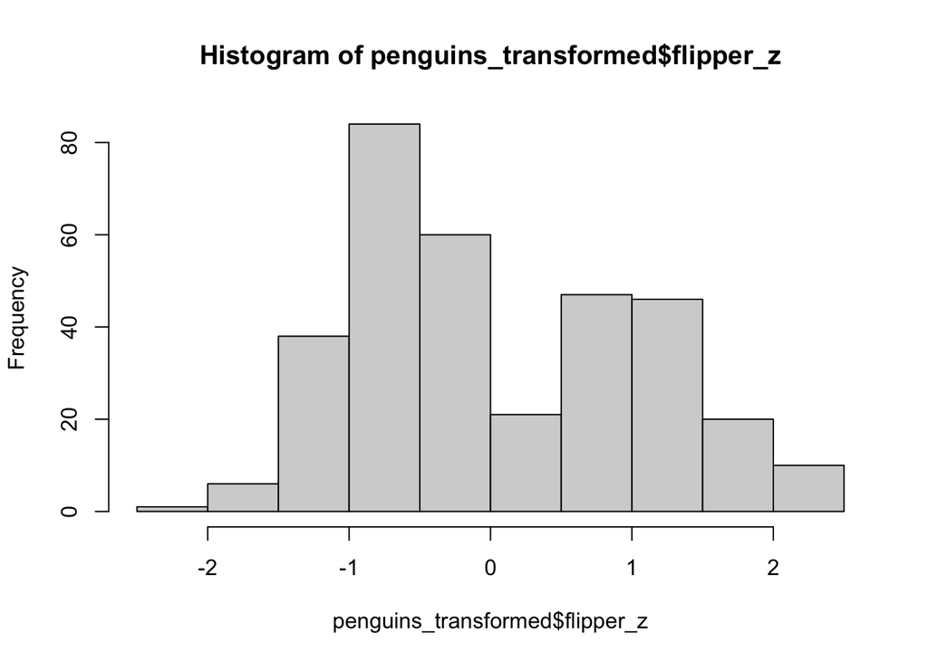

```r
penguins_transformed <- penguins_transformed %>%
  dplyr::mutate(
    flipper_z = as.numeric(scale(flipper_length_mm))
  )

hist(penguins_transformed$flipper_z)
```

**Questions**

1. What does `log()` do to a skewed variable?
2. What does a z-score represent?
3. Why might standardizing predictors be useful in advanced models?

## 12. Lab Challenge: Short Applied Practice

Now try a short workflow on your own.

### Exercise 17: Mini-analysis

Choose **one** numeric variable and **one** categorical variable from the dataset.

Your task:

1. inspect the variables
2. clean missing values if needed
3. summarize the numeric variable by the categorical variable
4. make one plot
5. write 2-3 sentences interpreting what you found

You can use this template:

```r
# Step 1: choose variables
# Example:
# numeric_var = body_mass_g
# categorical_var = species

mini_summary <- penguins %>%
  dplyr::filter(!is.na(body_mass_g), !is.na(species)) %>%
  dplyr::group_by(species) %>%
  dplyr::summarise(
    mean_value = mean(body_mass_g),
    n = dplyr::n()
  )

mini_summary
```

```
## # A tibble: 3 × 3
##   species   mean_value     n
##   <chr>          <dbl> <int>
## 1 Adelie         3706.   146
## 2 Chinstrap      3733.    68
## 3 Gentoo         5092.   119
```

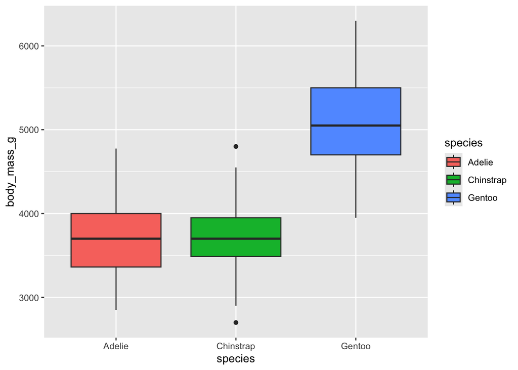

```r
ggplot2::ggplot(
  penguins %>% dplyr::filter(!is.na(body_mass_g), !is.na(species)),
  ggplot2::aes(x = species, y = body_mass_g, fill = species)
) +
  ggplot2::geom_boxplot()
```

## 13. Optional Challenge

If you finish early, try one or both of these:

### Challenge A

Fit a linear model with two predictors:

```r
mod2 <- lm(body_mass_g ~ flipper_length_mm + species, data = model_data)

summary(mod2)
```

```
##
## Call:
## lm(formula = body_mass_g ~ flipper_length_mm + species, data = model_data)
##
## Residuals:
##    Min     1Q Median     3Q    Max
## -898.8 -252.0  -24.8  229.8 1191.6
##
## Coefficients:
##                   Estimate Std. Error t value Pr(>|t|)
## (Intercept)       -4013.18     586.25  -6.846 3.74e-11 ***
## flipper_length_mm    40.61       3.08  13.186  < 2e-16 ***
## speciesChinstrap   -205.38      57.57  -3.568 0.000414 ***
## speciesGentoo       284.52      95.43   2.981 0.003083 **
## ---
## Signif. codes:  0 '***' 0.001 '**' 0.01 '*' 0.05 '.' 0.1 ' ' 1
##
## Residual standard error: 373.3 on 329 degrees of freedom
## Multiple R-squared:  0.787,  Adjusted R-squared:  0.7851
## F-statistic: 405.3 on 3 and 329 DF,  p-value: < 2.2e-16
```

**How does this model differ from the first one?**

### Challenge B

Make a scatterplot of bill length vs. body mass, colored by species, and add separate trend lines for each species.

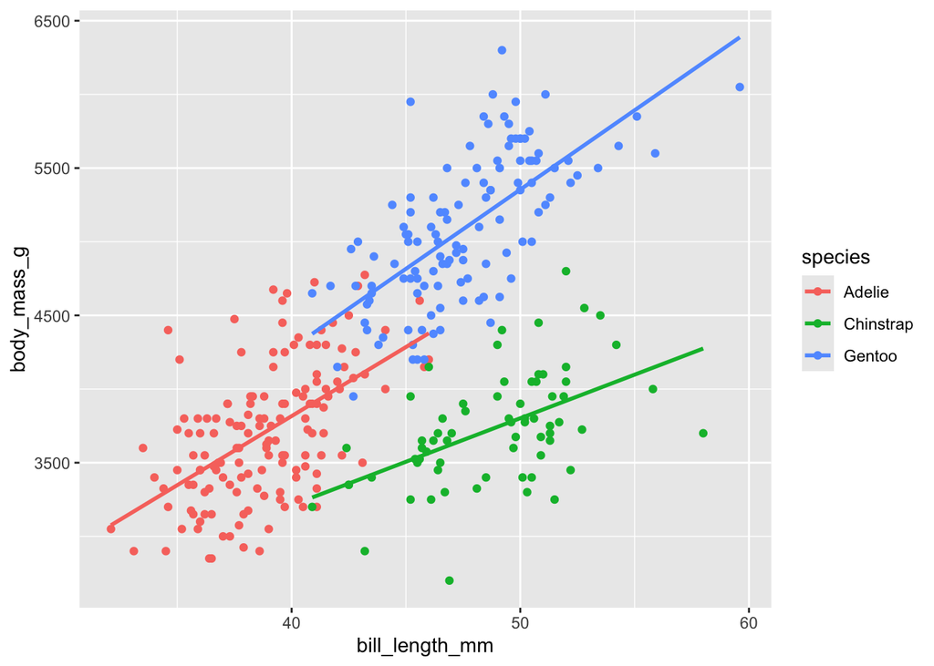

```r
penguins2 <- penguins %>% filter(!is.na(bill_length_mm) & !is.na(body_mass_g) & !is.na(species))
# removing any observations with missing data

ggplot2::ggplot(penguins2, aes(x = bill_length_mm, y = body_mass_g, color = species)) +
  geom_point() +
  geom_smooth(method = "lm", se = FALSE)
```

What do the species-specific patterns look like?

## Homework

Use **your own dataset** for a short refresher analysis.

### Homework task

Choose **one variable** from your own dataset and do the following:

1. clean or filter the data if needed
2. make one plot
3. write 3-4 sentences interpreting the variable
4. if possible, compare it across one grouping variable, such as sex, age class, location, group, treatment, or year

### What to submit

Submit an `.Rmd` or knitted output that includes:

- your code
- one figure
- a short written interpretation

## Final Reflection

Before the advanced course begins, make sure you can answer these questions:

- Can I set up and open an R Project?
- Can I check my working directory?
- Can I import a dataset and inspect its structure?
- Can I make quick exploratory summaries and plots?
- Can I filter rows and create new variables?
- Can I summarize values by group?
- Can I join two datasets correctly?
- Can I make and customize a basic plot?
- Can I fit and interpret a simple linear model?
- Can I explain why I used a transformation?

If not, revisit the relevant section and practice again.